# clustering

```python
%reload_ext autotime
import geopandas as gpd
import pandas as pd
import numpy as np
from matplotlib import pyplot as plt
from sklearn.cluster import KMeans
import plotly.express as px
from sklearn.preprocessing import StandardScaler
from shapely import box
pd.set_option('display.max_columns', 500)
```

```
time: 2.5 s (started: 2026-11-13 00:19:10 +00:00)
```

```python
df = gpd.read_parquet("../data/areas+NDVI.parquet").reset_index(drop=True)
df
```

|  | tile | geometry | area | in_river | split_by_river | old_min | old_max | old_mean | old_median | old_std | new_min | new_max | new_mean | new_median | new_std | diff_min | diff_max | diff_mean | diff_median | diff_std | distance_to_river | downslope_dist_min | downslope_dist_max | downslope_dist_mean | downslope_dist_median | downslope_dist_std | elevation_above_stream_min | elevation_above_stream_max | elevation_above_stream_mean | … |
| --- | --- | --- | --- | --- | --- | --- | --- | --- | --- | --- | --- | --- | --- | --- | --- | --- | --- | --- | --- | --- | --- | --- | --- | --- | --- | --- | --- | --- | --- | --- |
| 0 | BD43_10000_0204 | POLYGON ((2038720 5824277, 2038720 5824267, 20... | 109995.0 | False | False | 173.501007 | 376.213989 | 267.298783 | 268.329987 | 42.571095 | 172.826996 | 375.358002 | 265.746812 | 266.693024 | 42.575845 | -13.058990 | 7.561005 | -1.551971 | -1.221008 | 1.397520 | 127.175302 | NaN | NaN | NaN | NaN | NaN | -39.589996 | 169.254990 | 58.358777 | … |
| 1 | BD43_10000_0204 | POLYGON ((2038852 5824018, 2038852 5824017, 20... | 6862.0 | False | False | 150.063004 | 200.835007 | 174.480551 | 175.036003 | 11.866300 | 149.487991 | 200.264008 | 172.592442 | 172.374001 | 11.607059 | -5.774994 | 0.904999 | -1.888110 | -1.499496 | 1.263716 | 126.487060 | NaN | NaN | NaN | NaN | NaN | -56.895996 | -6.123993 | -32.478448 | … |
| 2 | BD43_10000_0205 | POLYGON ((2040289 5825821, 2040289 5825820, 20... | 1876258.0 | False | False | 66.085999 | 336.578003 | 190.008086 | 186.005005 | 47.516829 | 65.476997 | 336.058990 | 188.804323 | 184.852005 | 47.574112 | -11.596008 | 11.290009 | -1.203763 | -1.081985 | 1.255269 | 0.000000 | 0.000000 | 785.033630 | 178.822149 | 125.539108 | 160.302279 | -24.418015 | 203.816010 | 50.364654 | … |
| 3 | BD43_10000_0205 | POLYGON ((2042849 5825440, 2042849 5825439, 20... | 595540.0 | False | False | 34.811001 | 246.223007 | 114.778221 | 113.165001 | 38.660061 | 34.243000 | 245.533997 | 113.607786 | 112.064995 | 38.844805 | -15.232998 | 22.119003 | -1.170435 | -1.012001 | 1.680870 | 0.000000 | 0.000000 | 428.475189 | 80.034764 | 62.627419 | 68.713371 | -14.959999 | 177.075012 | 42.117074 | … |
| 4 | BD43_10000_0205 | POLYGON ((2041185 5826339, 2041185 5826337, 20... | 210041.0 | False | False | 56.733002 | 326.923981 | 160.069666 | 154.723007 | 55.436948 | 55.687000 | 326.404999 | 158.823676 | 153.395004 | 55.602677 | -10.728012 | 6.995972 | -1.245990 | -1.131004 | 1.362168 | 0.000000 | 0.000000 | 548.842712 | 156.494809 | 104.296463 | 143.111572 | -9.210999 | 202.423981 | 59.575413 | … |
| ... | ... | ... | ... | ... | ... | ... | ... | ... | ... | ... | ... | ... | ... | ... | ... | ... | ... | ... | ... | ... | ... | ... | ... | ... | ... | ... | ... | ... | ... | … |
| 22207 | BH43_10000_0301 | POLYGON ((2021523 5675802, 2021523 5675800, 20... | 4278.0 | False | False | 96.063995 | 170.550995 | 135.884838 | 136.414505 | 17.026771 | 95.452995 | 169.953003 | 133.936836 | 133.898499 | 16.997852 | -5.881004 | 0.451004 | -1.948003 | -1.686989 | 1.196088 | 43.422590 | 80.639610 | 266.107635 | 141.680997 | 140.852814 | 31.938640 | 5.129005 | 90.720001 | 45.310526 | … |
| 22208 | BH43_10000_0301 | POLYGON ((2022313 5676767, 2022313 5676766, 20... | 4199.0 | False | False | 220.692001 | 242.866989 | 232.474477 | 233.542007 | 4.579114 | 221.350998 | 243.551010 | 234.253400 | 234.847992 | 5.075268 | -0.694000 | 6.761993 | 1.778923 | 1.378006 | 1.243358 | 11.933590 | 0.000000 | 255.965515 | 127.109021 | 126.911690 | 77.429996 | -7.694000 | 13.492996 | 3.536662 | … |
| 22209 | BH43_10000_0302 | POLYGON ((2024856 5678734, 2024856 5678732, 20... | 9191.0 | False | False | 10.032000 | 96.386993 | 64.787314 | 69.517998 | 19.818413 | 9.427999 | 95.719994 | 58.861884 | 60.799999 | 19.550404 | -18.948994 | 1.702000 | -5.925430 | -4.676010 | 4.605385 | 42.218420 | 20.242641 | 204.124893 | 100.971630 | 98.254837 | 38.091454 | -12.841999 | 60.438999 | 22.457150 | … |
| 22210 | BH43_10000_0302 | POLYGON ((2025049 5679318, 2025049 5679316, 20... | 5912.0 | False | False | -0.951000 | 44.045002 | 5.253306 | 0.911500 | 9.220556 | -0.450000 | 44.028000 | 8.183538 | 3.809000 | 9.401518 | -4.831000 | 13.130000 | 2.930232 | 1.578000 | 3.140534 | 0.000000 | 0.000000 | 59.698486 | 11.271629 | 5.414214 | 13.496423 | -1.155000 | 44.088001 | 5.636965 | … |
| 22211 | BH43_10000_0302 | POLYGON ((2024932 5679145, 2024932 5679144, 20... | 4475.0 | False | False | 12.113000 | 116.617004 | 67.823627 | 67.661003 | 22.270409 | 11.250000 | 116.105003 | 58.937767 | 58.470001 | 18.856687 | -33.622993 | 5.277000 | -8.885860 | -6.648003 | 7.297860 | 28.465809 | 22.727922 | 147.811188 | 85.535681 | 86.012192 | 27.485237 | 6.808998 | 87.577995 | 51.779473 | … |

22212 rows × 195 columns

```
time: 1.27 s (started: 2026-11-13 00:19:12 +00:00)
```

## Weighted k-means

Each polygon has many features, but they are spread very unevenly across the variables they describe: every terrain attribute contributes 15 columns (5 statistics × old/new/diff), NDVI 15, each hydrological index 5, and `distance_to_river` just one. After standardisation every column has unit variance, so plain k-means weights each variable by its number of columns, and the 120 terrain columns dominate the clustering.

To correct for this, the standardised columns are grouped by the variable they describe and each column is multiplied by $\sqrt{w_g / n_g}$, where $n_g$ is the number of (non-constant) columns in group $g$ and $w_g$ its weight. Each group then contributes $w_g$ to the total variance, so with the default $w_g = 1$ every variable has the same influence on the squared Euclidean distances k-means uses. Change `GROUP_WEIGHTS` to emphasise a variable, or set its weight to 0 to leave it out.

The LCDB 2018 land-cover class and the GNS rock group are categories, so they are one-hot encoded rather than treated as numbers. Processing flags (`tile`, `split_by_river`) are not used as features.

```python
STATS = ["min", "max", "mean", "median", "std"]
TERRAIN = ["roughness", "slope", "aspect", "curvature", "terrain_ruggedness_index",
           "rugosity", "profile_curvature", "planform_curvature"]
HYDRO = ["downslope_dist", "elevation_above_stream", "depth_to_water", "twi", "spi", "connectivity_index"]
LOG_TRANSFORM = ["area", "rock_age"] + [f"spi_{s}" for s in STATS]  # heavily right-skewed, non-negative

def stat_cols(*prefixes):
    return [f"{p}_{s}" for p in prefixes for s in STATS]

# Land cover: one-hot encoded LCDB class plus the wetland/onshore flags
land_cover = pd.get_dummies(df["Class_2018"].astype("string"), prefix="lcdb", dtype=float)
for col in ["Wetland_18", "Onshore_18"]:
    land_cover[col] = df[col].astype("boolean").fillna(False).astype(float)
# Geology: one-hot encoded GNS rock group (e.g. mudstone, alternating sandstone/mudstone)
rock_type = (pd.get_dummies(df["rock_group"].astype("string"), prefix="rock", dtype=float)
             if "rock_group" in df else pd.DataFrame(index=df.index))
# 2023 land cover is after the change, so it's off by default (see GROUP_WEIGHTS)
land_cover_2023 = (pd.get_dummies(df["Class_2023"].astype("string"), prefix="lcdb23", dtype=float)
                   if "Class_2023" in df else pd.DataFrame(index=df.index))
categorical = pd.concat([land_cover, rock_type, land_cover_2023], axis=1)

feature_groups = {
    "elevation": stat_cols("old", "new"),
    "elevation_change": stat_cols("diff"),
    **{a: stat_cols(f"old_{a}", f"new_{a}", f"diff_{a}") for a in TERRAIN},
    **{h: stat_cols(h) for h in HYDRO},
    "ndvi": stat_cols("NDVI_old", "NDVI_new"),
    "ndvi_change": stat_cols("NDVI_diff"),
    "area": ["area"],
    "distance_to_river": ["distance_to_river"],
    "in_river": ["in_river"],
    "land_cover": list(land_cover.columns),
    "land_cover_2023": list(land_cover_2023.columns),
    "rock_type": list(rock_type.columns),
    "rock_age": ["rock_age"],
    "mapped_landslide": ["landslide_share"],
}
# Groups not listed get weight 1, e.g. {"elevation_change": 2, "aspect": 0}. 2023 land cover
# (LCDB v6.0) was mapped after the change, so it describes the outcome; set its weight above 0 to use it.
GROUP_WEIGHTS = {"land_cover_2023": 0}

features = pd.concat([df.drop(columns=categorical.columns.intersection(df.columns)), categorical], axis=1)
for group, cols in list(feature_groups.items()):
    present = [c for c in cols if c in features.columns]
    if len(present) < len(cols):
        print(f"{group}: {len(cols) - len(present)} of {len(cols)} columns missing")
    if present and GROUP_WEIGHTS.get(group, 1) > 0:
        feature_groups[group] = present
    else:
        del feature_groups[group]
columns = [c for cols in feature_groups.values() for c in cols]
X = features[columns].astype(float)
log_cols = X.columns.intersection(LOG_TRANSFORM)
X[log_cols] = np.log1p(X[log_cols])

# k-means needs complete rows
complete = X.notna().all(axis=1)
print(f"Dropping {(~complete).sum()} of {len(X)} polygons with missing values; most common gaps:")
print(X.isna().sum().sort_values(ascending=False).head(5).to_string())
df, X = df[complete].reset_index(drop=True), X[complete].reset_index(drop=True)
```

```
Dropping 167 of 22212 polygons with missing values; most common gaps:
downslope_dist_mean          101
downslope_dist_std           101
connectivity_index_median    101
connectivity_index_mean      101
connectivity_index_max       101
time: 57.7 ms (started: 2026-11-13 00:19:14 +00:00)
```

```python
scaled = pd.DataFrame(StandardScaler().fit_transform(X), columns=X.columns)
summary = []
for group, cols in feature_groups.items():
    weight = GROUP_WEIGHTS.get(group, 1)
    varying = max(int((X[cols].std(ddof=0) > 0).sum()), 1)  # constant columns carry no variance
    scaled[cols] *= np.sqrt(weight / varying)
    summary.append((group, len(cols), weight, scaled[cols].var(ddof=0).sum()))
summary = pd.DataFrame(summary, columns=["group", "columns", "weight", "variance"]).set_index("group")
summary["share_of_distance"] = summary.variance / summary.variance.sum()
summary
```

| group | columns | weight | variance | share_of_distance |
| --- | --- | --- | --- | --- |
| elevation | 10 | 1 | 1.0 | 0.04 |
| elevation_change | 5 | 1 | 1.0 | 0.04 |
| roughness | 15 | 1 | 1.0 | 0.04 |
| slope | 15 | 1 | 1.0 | 0.04 |
| aspect | 15 | 1 | 1.0 | 0.04 |
| curvature | 15 | 1 | 1.0 | 0.04 |
| terrain_ruggedness_index | 15 | 1 | 1.0 | 0.04 |
| rugosity | 15 | 1 | 1.0 | 0.04 |
| profile_curvature | 15 | 1 | 1.0 | 0.04 |
| planform_curvature | 15 | 1 | 1.0 | 0.04 |
| downslope_dist | 5 | 1 | 1.0 | 0.04 |
| elevation_above_stream | 5 | 1 | 1.0 | 0.04 |
| depth_to_water | 5 | 1 | 1.0 | 0.04 |
| twi | 5 | 1 | 1.0 | 0.04 |
| spi | 5 | 1 | 1.0 | 0.04 |
| connectivity_index | 5 | 1 | 1.0 | 0.04 |
| ndvi | 10 | 1 | 1.0 | 0.04 |
| ndvi_change | 5 | 1 | 1.0 | 0.04 |
| area | 1 | 1 | 1.0 | 0.04 |
| distance_to_river | 1 | 1 | 1.0 | 0.04 |
| in_river | 1 | 1 | 1.0 | 0.04 |
| land_cover | 32 | 1 | 1.0 | 0.04 |
| rock_type | 12 | 1 | 1.0 | 0.04 |
| rock_age | 1 | 1 | 1.0 | 0.04 |
| mapped_landslide | 1 | 1 | 1.0 | 0.04 |

```
time: 173 ms (started: 2026-11-13 00:19:14 +00:00)
```

```
<BarContainer object of 25 artists>
```

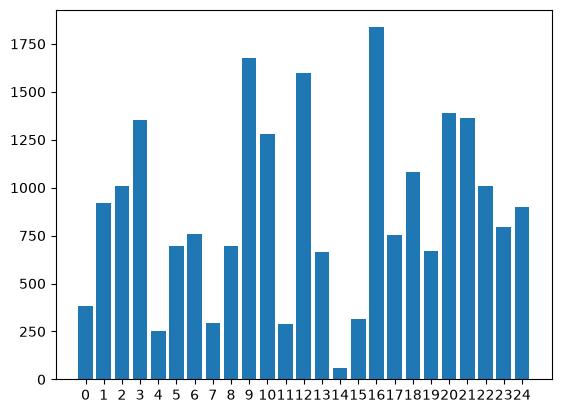

```
time: 3.98 s (started: 2026-11-13 00:19:14 +00:00)
```

```python
clusters = KMeans(n_clusters=25, n_init=10, random_state=0).fit_predict(scaled)
unique_values, counts = np.unique(clusters, return_counts=True)
plt.bar(unique_values.astype(str), counts)
```

```python
df["cluster"] = clusters
```

```
time: 992 μs (started: 2026-11-13 00:19:18 +00:00)
```

```python
df.to_parquet("../data/clusters.parquet")
```

```
time: 2.24 s (started: 2026-11-13 00:19:18 +00:00)
```

```python
df.to_file("../data/clusters.gpkg")
```

```
time: 1.81 s (started: 2026-11-13 00:19:20 +00:00)
```

```python
bbox = box(2053600, 5802000, 2058400, 5809200)
subset = df[df.within(bbox)]
display(subset.cluster.value_counts())
print(subset.shape)
subset.explore("cluster", legend=True, tooltip=["cluster", "area", "distance_to_river"] + df.columns[df.columns.str.startswith("diff")].tolist(), categorical=True, tiles="ESRI.WorldImagery")
```

```
cluster
20    38
2     19
21    19
16    18
1     16
3     13
8     12
19    11
18    11
5      9
13     8
22     6
7      3
12     2
17     2
9      1
Name: count, dtype: int64
```

```
(188, 196)
```

Make this Notebook Trusted to load map: File -> Trust Notebook

[interactive chart not shown]

```
time: 1.1 s (started: 2026-11-13 00:19:22 +00:00)
```